# P4-MPDW: Pembangkitan Proses MA(2), AR(2), dan ARMA(2,2)

# 3 Pembangkitan Model ARMA(2,2)

Bentuk umum persamaan model ARMA(2,2):
$$Y_t = \phi_1 Y_{t-1} + \phi_2 Y_{t-2} + e_t +
\theta_1 e_{t-1} + \theta_2 e_{t-2}$$
dengan parameter $\phi_1 = 0.5$, $\phi_2 = 0.2$, $\theta_1 = 0.4$, $\theta_2 = 0.6$, dan $e_t \sim \text{WN}(0, \sigma^2)$.

Kestasioneran model ARMA ditentukan oleh komponen AR: 1. $\phi_1 + \phi_2 = 0.5 + 0.2 = 0.7 < 1$ 2. $\phi_2 - \phi_1 = 0.2 - 0.5 = -0.3 < 1$ 3. $\vert{}\phi_2\vert{} = \vert{}0.2\vert{} < 1$

Ketiga syarat kestasioneran terpenuhi, sehingga proses ARMA(2,2) ini dipastikan **stasioner**.

## 3.1 1. Pembangkitan Data

### 3.1.1 Menggunakan `arima.sim`

```r
set.seed(123)
n <- 300
phi1 <- 0.5
phi2 <- 0.2
theta1 <- 0.4
theta2 <- 0.6

# Menggunakan arima.sim
arma22 <- arima.sim(list(order = c(2, 0, 2),
                         ar = c(phi1, phi2),
                         ma = c(theta1, theta2)),
                    n = n)
head(arma22, 10)
```

```
## Time Series:
## Start = 1
## End = 10
## Frequency = 1
##  [1] -3.11187150 -2.78699743 -1.12528900 -0.87493596 -0.03472262  0.84062710
##  [7]  1.47250989  2.61429024  3.14579988  3.41808039
```

### 3.1.2 Pembangkitan Manual

```r
# Pembangkitan Manual
set.seed(123)
# Bangkitkan white noise e_t sebanyak n + 2
e <- rnorm(n + 2, mean = 0, sd = 1)
arma22_manual <- numeric(n)

# Nilai awal Y_1 dan Y_2
arma22_manual[1] <- e[3] + theta1 * e[2] + theta2 * e[1]
arma22_manual[2] <- phi1 * arma22_manual[1] + e[4] + theta1 * e[3] + theta2 * e[2]

# Perulangan untuk t = 3 hingga n
for (t in 3:n) {
  arma22_manual[t] <- phi1 * arma22_manual[t - 1] +
                      phi2 * arma22_manual[t - 2] +
                      e[t + 2] +
                      theta1 * e[t + 1] +
                      theta2 * e[t]
}

head(arma22_manual, 10)
```

```
##  [1]  1.1303519  1.1210612  1.8793171  2.9729559  3.0868562  2.0863635
##  [7]  0.7442254 -0.6900545  0.4375231  0.6628000
```

## 3.2 Karakteristik ARMA(2,2) & Uji Kestasioneran

### 3.2.1 Plot Time Series

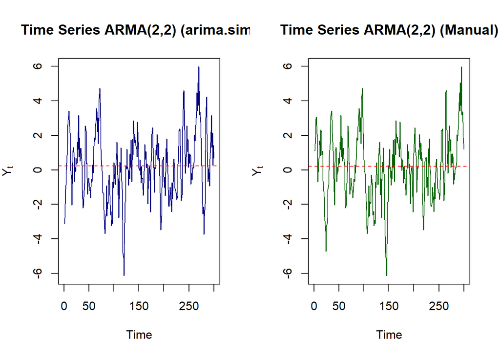

```r
par(mfrow = c(1, 2))
ts.plot(arma22, col = "navy",
        main = "Time Series ARMA(2,2) (arima.sim)",
        ylab = expression(Y[t]))
abline(h = mean(arma22), col = "red", lty = 2)

ts.plot(arma22_manual, col = "darkgreen",
        main = "Time Series ARMA(2,2) (Manual)",
        ylab = expression(Y[t]))
abline(h = mean(arma22_manual), col = "red", lty = 2)
```

```r
par(mfrow = c(1, 1))
```

### 3.2.2 Plot ACF

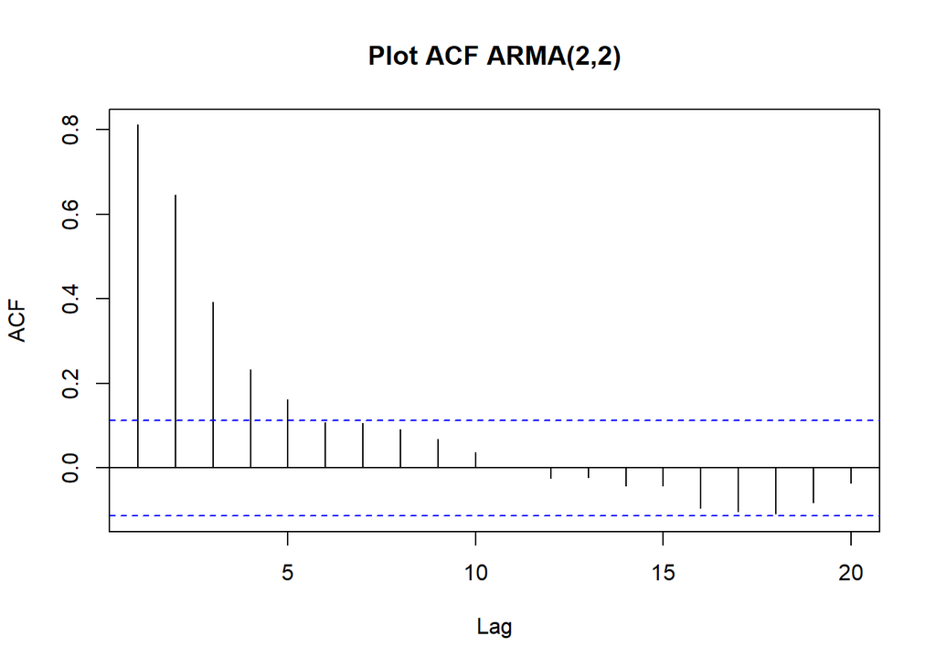

```r
acf(arma22, lag.max = 20, main = "Plot ACF ARMA(2,2)")
```

### 3.2.3 Plot PACF

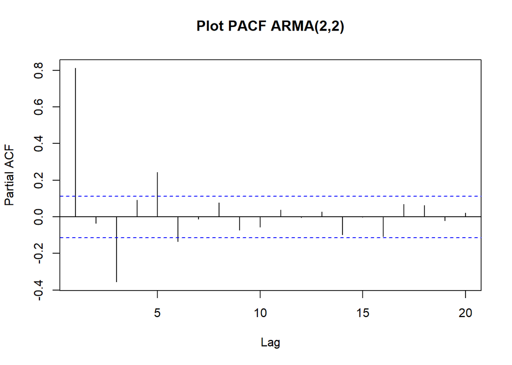

```r
pacf(arma22, lag.max = 20, main = "Plot PACF ARMA(2,2)")
```

### 3.2.4 Plot EACF

```r
TSA::eacf(arma22)
```

```
## AR/MA
##   0 1 2 3 4 5 6 7 8 9 10 11 12 13
## 0 x x x x x o o o o o o  o  o  o
## 1 o x o o o x o o o o o  o  o  o
## 2 o x o o o x o o o o o  o  o  o
## 3 x x o x o x o o o o o  o  o  o
## 4 x x o x o x o o o o o  o  o  o
## 5 x x o x x o o o o o o  o  o  o
## 6 x x o x x o o o o o o  o  o  o
## 7 x x x x x o o o o o o  o  o  o
```

## 3.3 Scatterplot Antar Lag

### 3.3.1 Korelasi antara $Y_t$ dengan $Y_{t-1}$

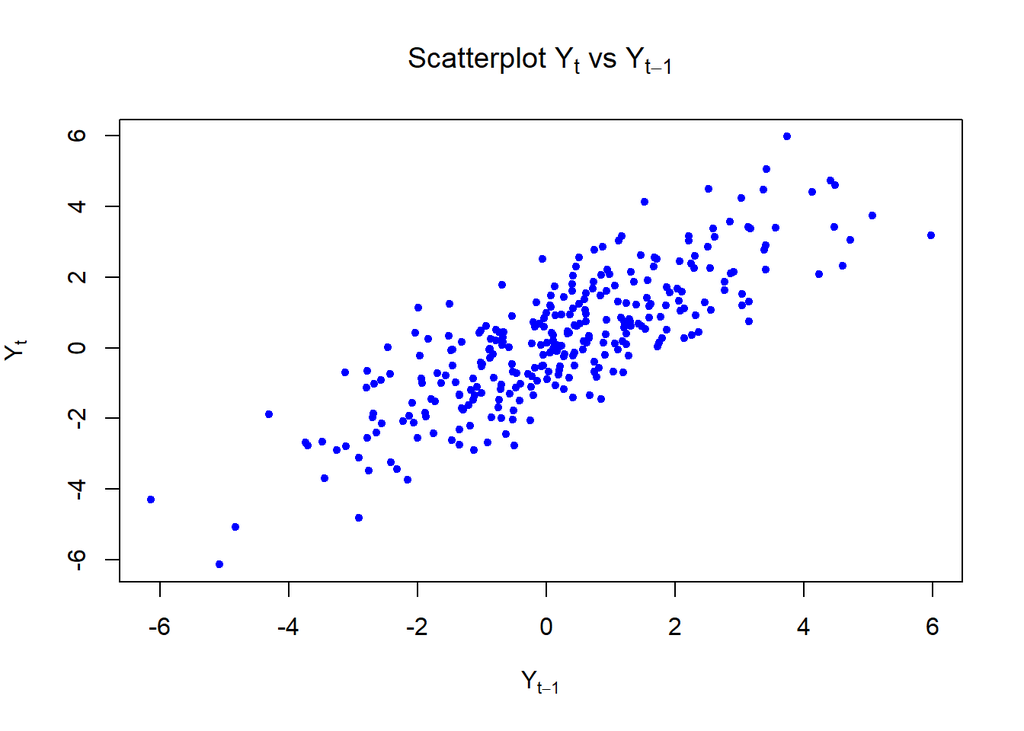

```r
yt_arma1 <- arma22[-1]
yt_1_arma <- arma22[-n]

plot(yt_1_arma, yt_arma1,
     main = expression(paste("Scatterplot ", Y[t], " vs ", Y[t-1])),
     xlab = expression(Y[t-1]), ylab = expression(Y[t]),
     pch = 20, col = "blue")
```

```r
cor(yt_arma1, yt_1_arma)
```

```
## [1] 0.815228
```

### 3.3.2 Korelasi antara $Y_t$ dengan $Y_{t-2}$

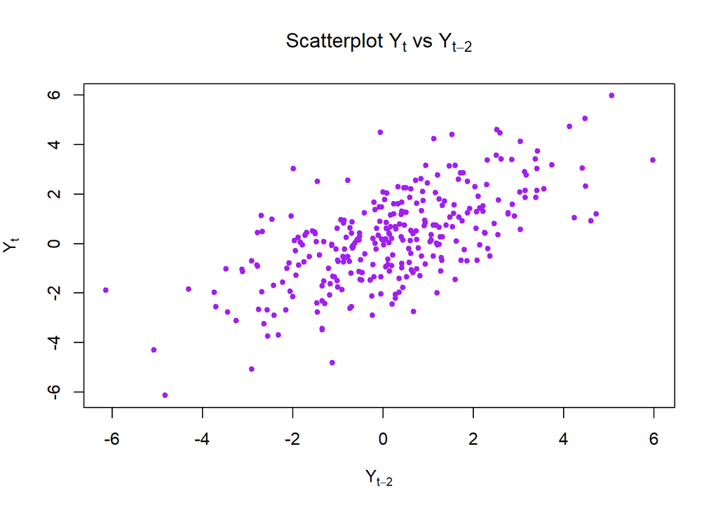

```r
yt_arma2 <- arma22[-c(1, 2)]
yt_2_arma <- arma22[-c(n - 1, n)]

plot(yt_2_arma, yt_arma2,
     main = expression(paste("Scatterplot ", Y[t], " vs ", Y[t-2])),
     xlab = expression(Y[t-2]), ylab = expression(Y[t]),
     pch = 20, col = "purple")
```

```r
cor(yt_arma2, yt_2_arma)
```

```
## [1] 0.6523184
```